# Multi linear regression car_price assignment

Data understanding

```python
import numpy as np
import pandas as pd
```

```python
#reading csv file
data=pd.read_csv('CarPrice_Assignment.csv')
data.head()
```

|  | car_ID | symboling | CarName | fueltype | aspiration | doornumber | carbody | drivewheel | enginelocation | wheelbase | ... | enginesize | fuelsystem | boreratio | stroke | compressionratio | horsepower | peakrpm | citympg | highwaympg | price |
| --- | --- | --- | --- | --- | --- | --- | --- | --- | --- | --- | --- | --- | --- | --- | --- | --- | --- | --- | --- | --- | --- |
| 0 | 1 | 3 | alfa-romero giulia | gas | std | two | convertible | rwd | front | 88.6 | ... | 130 | mpfi | 3.47 | 2.68 | 9.0 | 111 | 5000 | 21 | 27 | 13495.0 |
| 1 | 2 | 3 | alfa-romero stelvio | gas | std | two | convertible | rwd | front | 88.6 | ... | 130 | mpfi | 3.47 | 2.68 | 9.0 | 111 | 5000 | 21 | 27 | 16500.0 |
| 2 | 3 | 1 | alfa-romero Quadrifoglio | gas | std | two | hatchback | rwd | front | 94.5 | ... | 152 | mpfi | 2.68 | 3.47 | 9.0 | 154 | 5000 | 19 | 26 | 16500.0 |
| 3 | 4 | 2 | audi 100 ls | gas | std | four | sedan | fwd | front | 99.8 | ... | 109 | mpfi | 3.19 | 3.40 | 10.0 | 102 | 5500 | 24 | 30 | 13950.0 |
| 4 | 5 | 2 | audi 100ls | gas | std | four | sedan | 4wd | front | 99.4 | ... | 136 | mpfi | 3.19 | 3.40 | 8.0 | 115 | 5500 | 18 | 22 | 17450.0 |

5 rows × 26 columns

```python
#last five rows
data.tail()
```

|  | car_ID | symboling | CarName | fueltype | aspiration | doornumber | carbody | drivewheel | enginelocation | wheelbase | ... | enginesize | fuelsystem | boreratio | stroke | compressionratio | horsepower | peakrpm | citympg | highwaympg | price |
| --- | --- | --- | --- | --- | --- | --- | --- | --- | --- | --- | --- | --- | --- | --- | --- | --- | --- | --- | --- | --- | --- |
| 200 | 201 | -1 | volvo 145e (sw) | gas | std | four | sedan | rwd | front | 109.1 | ... | 141 | mpfi | 3.78 | 3.15 | 9.5 | 114 | 5400 | 23 | 28 | 16845.0 |
| 201 | 202 | -1 | volvo 144ea | gas | turbo | four | sedan | rwd | front | 109.1 | ... | 141 | mpfi | 3.78 | 3.15 | 8.7 | 160 | 5300 | 19 | 25 | 19045.0 |
| 202 | 203 | -1 | volvo 244dl | gas | std | four | sedan | rwd | front | 109.1 | ... | 173 | mpfi | 3.58 | 2.87 | 8.8 | 134 | 5500 | 18 | 23 | 21485.0 |
| 203 | 204 | -1 | volvo 246 | diesel | turbo | four | sedan | rwd | front | 109.1 | ... | 145 | idi | 3.01 | 3.40 | 23.0 | 106 | 4800 | 26 | 27 | 22470.0 |
| 204 | 205 | -1 | volvo 264gl | gas | turbo | four | sedan | rwd | front | 109.1 | ... | 141 | mpfi | 3.78 | 3.15 | 9.5 | 114 | 5400 | 19 | 25 | 22625.0 |

5 rows × 26 columns

```python
#205 rows and 26 col
data.shape
```

```
(205, 26)
```

```python
# information about the col and its data type
data.info()
```

```
<class 'pandas.core.frame.DataFrame'>
RangeIndex: 205 entries, 0 to 204
Data columns (total 26 columns):
car_ID              205 non-null int64
symboling           205 non-null int64
CarName             205 non-null object
fueltype            205 non-null object
aspiration          205 non-null object
doornumber          205 non-null object
carbody             205 non-null object
drivewheel          205 non-null object
enginelocation      205 non-null object
wheelbase           205 non-null float64
carlength           205 non-null float64
carwidth            205 non-null float64
carheight           205 non-null float64
curbweight          205 non-null int64
enginetype          205 non-null object
cylindernumber      205 non-null object
enginesize          205 non-null int64
fuelsystem          205 non-null object
boreratio           205 non-null float64
stroke              205 non-null float64
compressionratio    205 non-null float64
horsepower          205 non-null int64
peakrpm             205 non-null int64
citympg             205 non-null int64
highwaympg          205 non-null int64
price               205 non-null float64
dtypes: float64(8), int64(8), object(10)
memory usage: 41.7+ KB
```

```python
#statistical information about the data
data.describe()
```

|  | car_ID | symboling | wheelbase | carlength | carwidth | carheight | curbweight | enginesize | boreratio | stroke | compressionratio | horsepower | peakrpm | citympg | highwaympg | price |
| --- | --- | --- | --- | --- | --- | --- | --- | --- | --- | --- | --- | --- | --- | --- | --- | --- |
| count | 205.000000 | 205.000000 | 205.000000 | 205.000000 | 205.000000 | 205.000000 | 205.000000 | 205.000000 | 205.000000 | 205.000000 | 205.000000 | 205.000000 | 205.000000 | 205.000000 | 205.000000 | 205.000000 |
| mean | 103.000000 | 0.834146 | 98.756585 | 174.049268 | 65.907805 | 53.724878 | 2555.565854 | 126.907317 | 3.329756 | 3.255415 | 10.142537 | 104.117073 | 5125.121951 | 25.219512 | 30.751220 | 13276.710571 |
| std | 59.322565 | 1.245307 | 6.021776 | 12.337289 | 2.145204 | 2.443522 | 520.680204 | 41.642693 | 0.270844 | 0.313597 | 3.972040 | 39.544167 | 476.985643 | 6.542142 | 6.886443 | 7988.852332 |
| min | 1.000000 | -2.000000 | 86.600000 | 141.100000 | 60.300000 | 47.800000 | 1488.000000 | 61.000000 | 2.540000 | 2.070000 | 7.000000 | 48.000000 | 4150.000000 | 13.000000 | 16.000000 | 5118.000000 |
| 25% | 52.000000 | 0.000000 | 94.500000 | 166.300000 | 64.100000 | 52.000000 | 2145.000000 | 97.000000 | 3.150000 | 3.110000 | 8.600000 | 70.000000 | 4800.000000 | 19.000000 | 25.000000 | 7788.000000 |
| 50% | 103.000000 | 1.000000 | 97.000000 | 173.200000 | 65.500000 | 54.100000 | 2414.000000 | 120.000000 | 3.310000 | 3.290000 | 9.000000 | 95.000000 | 5200.000000 | 24.000000 | 30.000000 | 10295.000000 |
| 75% | 154.000000 | 2.000000 | 102.400000 | 183.100000 | 66.900000 | 55.500000 | 2935.000000 | 141.000000 | 3.580000 | 3.410000 | 9.400000 | 116.000000 | 5500.000000 | 30.000000 | 34.000000 | 16503.000000 |
| max | 205.000000 | 3.000000 | 120.900000 | 208.100000 | 72.300000 | 59.800000 | 4066.000000 | 326.000000 | 3.940000 | 4.170000 | 23.000000 | 288.000000 | 6600.000000 | 49.000000 | 54.000000 | 45400.000000 |

```python
#finding sum of  null values in each col
data.isnull().sum()
```

```
car_ID              0
symboling           0
CarName             0
fueltype            0
aspiration          0
doornumber          0
carbody             0
drivewheel          0
enginelocation      0
wheelbase           0
carlength           0
carwidth            0
carheight           0
curbweight          0
enginetype          0
cylindernumber      0
enginesize          0
fuelsystem          0
boreratio           0
stroke              0
compressionratio    0
horsepower          0
peakrpm             0
citympg             0
highwaympg          0
price               0
dtype: int64
```

There are no null values in each columns so the data is cleaned

# Data preparation

```python
data.head()
```

|  | car_ID | symboling | CarName | fueltype | aspiration | doornumber | carbody | drivewheel | enginelocation | wheelbase | ... | enginesize | fuelsystem | boreratio | stroke | compressionratio | horsepower | peakrpm | citympg | highwaympg | price |
| --- | --- | --- | --- | --- | --- | --- | --- | --- | --- | --- | --- | --- | --- | --- | --- | --- | --- | --- | --- | --- | --- |
| 0 | 1 | 3 | alfa-romero giulia | gas | std | two | convertible | rwd | front | 88.6 | ... | 130 | mpfi | 3.47 | 2.68 | 9.0 | 111 | 5000 | 21 | 27 | 13495.0 |
| 1 | 2 | 3 | alfa-romero stelvio | gas | std | two | convertible | rwd | front | 88.6 | ... | 130 | mpfi | 3.47 | 2.68 | 9.0 | 111 | 5000 | 21 | 27 | 16500.0 |
| 2 | 3 | 1 | alfa-romero Quadrifoglio | gas | std | two | hatchback | rwd | front | 94.5 | ... | 152 | mpfi | 2.68 | 3.47 | 9.0 | 154 | 5000 | 19 | 26 | 16500.0 |
| 3 | 4 | 2 | audi 100 ls | gas | std | four | sedan | fwd | front | 99.8 | ... | 109 | mpfi | 3.19 | 3.40 | 10.0 | 102 | 5500 | 24 | 30 | 13950.0 |
| 4 | 5 | 2 | audi 100ls | gas | std | four | sedan | 4wd | front | 99.4 | ... | 136 | mpfi | 3.19 | 3.40 | 8.0 | 115 | 5500 | 18 | 22 | 17450.0 |

5 rows × 26 columns

```python
data.CarName.unique()
```

```
array(['alfa-romero giulia', 'alfa-romero stelvio',
       'alfa-romero Quadrifoglio', 'audi 100 ls', 'audi 100ls', 'audi fox',
       'audi 5000', 'audi 4000', 'audi 5000s (diesel)', 'bmw 320i',
       'bmw x1', 'bmw x3', 'bmw z4', 'bmw x4', 'bmw x5',
       'chevrolet impala', 'chevrolet monte carlo', 'chevrolet vega 2300',
       'dodge rampage', 'dodge challenger se', 'dodge d200',
       'dodge monaco (sw)', 'dodge colt hardtop', 'dodge colt (sw)',
       'dodge coronet custom', 'dodge dart custom',
       'dodge coronet custom (sw)', 'honda civic', 'honda civic cvcc',
       'honda accord cvcc', 'honda accord lx', 'honda civic 1500 gl',
       'honda accord', 'honda civic 1300', 'honda prelude',
       'honda civic (auto)', 'isuzu MU-X', 'isuzu D-Max ',
       'isuzu D-Max V-Cross', 'jaguar xj', 'jaguar xf', 'jaguar xk',
       'maxda rx3', 'maxda glc deluxe', 'mazda rx2 coupe', 'mazda rx-4',
       'mazda glc deluxe', 'mazda 626', 'mazda glc', 'mazda rx-7 gs',
       'mazda glc 4', 'mazda glc custom l', 'mazda glc custom',
       'buick electra 225 custom', 'buick century luxus (sw)',
       'buick century', 'buick skyhawk', 'buick opel isuzu deluxe',
       'buick skylark', 'buick century special',
       'buick regal sport coupe (turbo)', 'mercury cougar',
       'mitsubishi mirage', 'mitsubishi lancer', 'mitsubishi outlander',
       'mitsubishi g4', 'mitsubishi mirage g4', 'mitsubishi montero',
       'mitsubishi pajero', 'Nissan versa', 'nissan gt-r', 'nissan rogue',
       'nissan latio', 'nissan titan', 'nissan leaf', 'nissan juke',
       'nissan note', 'nissan clipper', 'nissan nv200', 'nissan dayz',
       'nissan fuga', 'nissan otti', 'nissan teana', 'nissan kicks',
       'peugeot 504', 'peugeot 304', 'peugeot 504 (sw)', 'peugeot 604sl',
       'peugeot 505s turbo diesel', 'plymouth fury iii',
       'plymouth cricket', 'plymouth satellite custom (sw)',
       'plymouth fury gran sedan', 'plymouth valiant', 'plymouth duster',
       'porsche macan', 'porcshce panamera', 'porsche cayenne',
       'porsche boxter', 'renault 12tl', 'renault 5 gtl', 'saab 99e',
       'saab 99le', 'saab 99gle', 'subaru', 'subaru dl', 'subaru brz',
       'subaru baja', 'subaru r1', 'subaru r2', 'subaru trezia',
       'subaru tribeca', 'toyota corona mark ii', 'toyota corona',
       'toyota corolla 1200', 'toyota corona hardtop',
       'toyota corolla 1600 (sw)', 'toyota carina', 'toyota mark ii',
       'toyota corolla', 'toyota corolla liftback',
       'toyota celica gt liftback', 'toyota corolla tercel',
       'toyota corona liftback', 'toyota starlet', 'toyota tercel',
       'toyota cressida', 'toyota celica gt', 'toyouta tercel',
       'vokswagen rabbit', 'volkswagen 1131 deluxe sedan',
       'volkswagen model 111', 'volkswagen type 3', 'volkswagen 411 (sw)',
       'volkswagen super beetle', 'volkswagen dasher', 'vw dasher',
       'vw rabbit', 'volkswagen rabbit', 'volkswagen rabbit custom',
       'volvo 145e (sw)', 'volvo 144ea', 'volvo 244dl', 'volvo 245',
       'volvo 264gl', 'volvo diesel', 'volvo 246'], dtype=object)
```

```python
data['CarName'] = data['CarName'].str.split(' ',expand=True)
data['CarName'].unique()
```

```
array(['alfa-romero', 'audi', 'bmw', 'chevrolet', 'dodge', 'honda',
       'isuzu', 'jaguar', 'maxda', 'mazda', 'buick', 'mercury',
       'mitsubishi', 'Nissan', 'nissan', 'peugeot', 'plymouth', 'porsche',
       'porcshce', 'renault', 'saab', 'subaru', 'toyota', 'toyouta',
       'vokswagen', 'volkswagen', 'vw', 'volvo'], dtype=object)
```

Fixing invalid values in company name column because it has some spelling mistakes we can do this by replacing it with right names...replace()

maxda=mazda nissan=Nissan porcshce=porsche toyouta=toyota vokswagwn=vw=volkswagen

```python
data.CarName = data.CarName.str.lower()

def replace_name(a,b):
    data.CarName.replace(a,b,inplace=True)

replace_name('maxda','mazda')
replace_name('porcshce','porsche')
replace_name('toyouta','toyota')
replace_name('vokswagen','volkswagen')
replace_name('vw','volkswagen')

data.CarName.unique()
```

```
array(['alfa-romero', 'audi', 'bmw', 'chevrolet', 'dodge', 'honda',
       'isuzu', 'jaguar', 'mazda', 'buick', 'mercury', 'mitsubishi',
       'nissan', 'peugeot', 'plymouth', 'porsche', 'renault', 'saab',
       'subaru', 'toyota', 'volkswagen', 'volvo'], dtype=object)
```

```python
#checking for duplicates
data.duplicated().sum()
```

```
0
```

No duplicates in the data

```python
data.columns
```

```
Index(['car_ID', 'symboling', 'CarName', 'fueltype', 'aspiration',
       'doornumber', 'carbody', 'drivewheel', 'enginelocation', 'wheelbase',
       'carlength', 'carwidth', 'carheight', 'curbweight', 'enginetype',
       'cylindernumber', 'enginesize', 'fuelsystem', 'boreratio', 'stroke',
       'compressionratio', 'horsepower', 'peakrpm', 'citympg', 'highwaympg',
       'price'],
      dtype='object')
```

# Data visualization

```python
import matplotlib.pyplot as plt
import seaborn as sns
%matplotlib inline
```

```python
data.head()
```

|  | car_ID | symboling | CarName | fueltype | aspiration | doornumber | carbody | drivewheel | enginelocation | wheelbase | ... | enginesize | fuelsystem | boreratio | stroke | compressionratio | horsepower | peakrpm | citympg | highwaympg | price |
| --- | --- | --- | --- | --- | --- | --- | --- | --- | --- | --- | --- | --- | --- | --- | --- | --- | --- | --- | --- | --- | --- |
| 0 | 1 | 3 | alfa-romero | gas | std | two | convertible | rwd | front | 88.6 | ... | 130 | mpfi | 3.47 | 2.68 | 9.0 | 111 | 5000 | 21 | 27 | 13495.0 |
| 1 | 2 | 3 | alfa-romero | gas | std | two | convertible | rwd | front | 88.6 | ... | 130 | mpfi | 3.47 | 2.68 | 9.0 | 111 | 5000 | 21 | 27 | 16500.0 |
| 2 | 3 | 1 | alfa-romero | gas | std | two | hatchback | rwd | front | 94.5 | ... | 152 | mpfi | 2.68 | 3.47 | 9.0 | 154 | 5000 | 19 | 26 | 16500.0 |
| 3 | 4 | 2 | audi | gas | std | four | sedan | fwd | front | 99.8 | ... | 109 | mpfi | 3.19 | 3.40 | 10.0 | 102 | 5500 | 24 | 30 | 13950.0 |
| 4 | 5 | 2 | audi | gas | std | four | sedan | 4wd | front | 99.4 | ... | 136 | mpfi | 3.19 | 3.40 | 8.0 | 115 | 5500 | 18 | 22 | 17450.0 |

5 rows × 26 columns

# Visualising Categorical Data

- CompanyName
- Symboling
- fueltype
- enginetype
- carbody
- doornumber
- enginelocation
- fuelsystem
- cylindernumber
- aspiration
- drivewheel

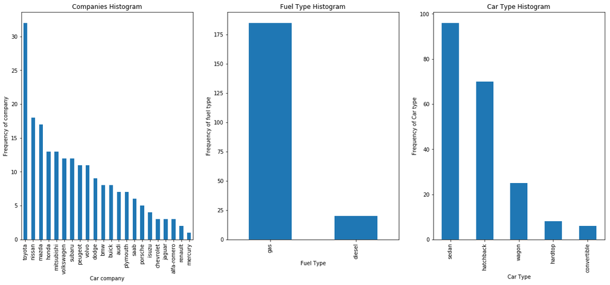

```python
plt.figure(figsize=(20, 8))

plt.subplot(1,3,1)
plt1 = data.CarName.value_counts().plot('bar')
plt.title('Companies Histogram')
plt1.set(xlabel = 'Car company', ylabel='Frequency of company')

plt.subplot(1,3,2)
plt1 = data.fueltype.value_counts().plot('bar')
plt.title('Fuel Type Histogram')
plt1.set(xlabel = 'Fuel Type', ylabel='Frequency of fuel type')

plt.subplot(1,3,3)
plt1 = data.carbody.value_counts().plot('bar')
plt.title('Car Type Histogram')
plt1.set(xlabel = 'Car Type', ylabel='Frequency of Car type')

plt.show()
```

Inference : Toyota seemed to be favored car company. Number of gas fueled cars are more than diesel. sedan is the top car type prefered.

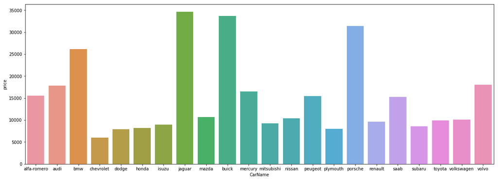

```python
plt.figure(figsize=[20,7])
sns.barplot(x=data.CarName,y=data.price,ci=None)
```

jaguar has higest price ,jaguar,buick,bmw,porsche these car comany shows high price than others.chevrolet has minimum price.

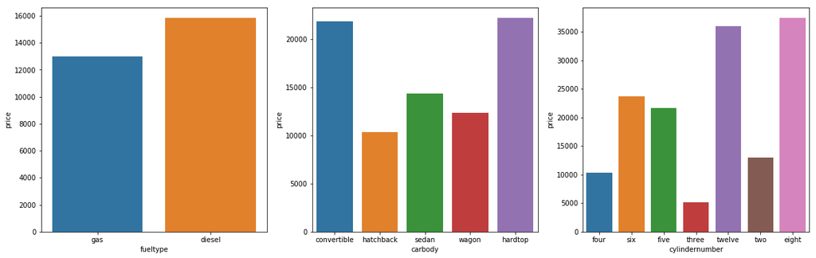

```python
plt.figure(figsize=(20, 6))

plt.subplot(1,3,1)
plt1 = sns.barplot(x=data.fueltype,y=data.price,ci=None)

plt.subplot(1,3,2)
plt1 = sns.barplot(x=data.carbody,y=data.price,ci=None)

plt.subplot(1,3,3)
plt1 = sns.barplot(x=data.cylindernumber,y=data.price,ci=None)

plt.show()
```

Diesel cars are more costly than petrol cars. hardtop and convertible are high in price. car with cylinder number eight and twelve are high in price.

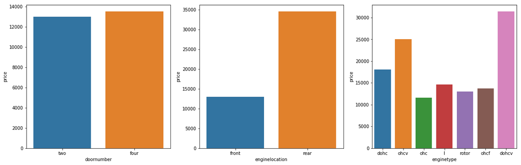

```python
plt.figure(figsize=(20, 6))

plt.subplot(1,3,1)
plt1 = sns.barplot(x=data.doornumber,y=data.price,ci=None)

plt.subplot(1,3,2)
plt1 = sns.barplot(x=data.enginelocation,y=data.price,ci=None)

plt.subplot(1,3,3)
plt1 = sns.barplot(x=data.enginetype,y=data.price,ci=None)

plt.show()
```

doornumber variable is not affacting the price much. There is no significant difference between the categories in it. rear engine location has highest price range. engine type=dohcv is having higest price range.

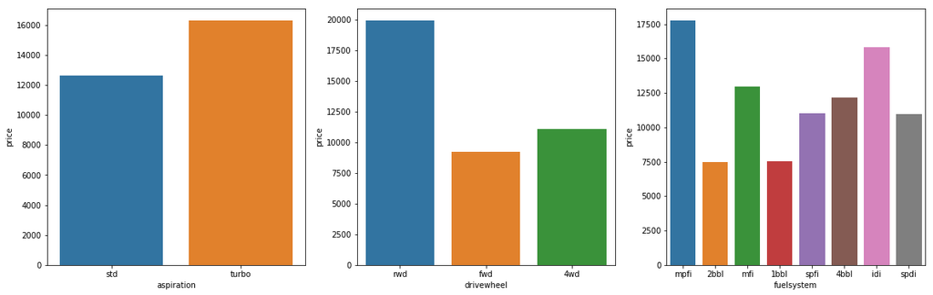

```python
plt.figure(figsize=(20, 6))

plt.subplot(1,3,1)
plt1 = sns.barplot(x=data.aspiration,y=data.price,ci=None)

plt.subplot(1,3,2)
plt1 = sns.barplot(x=data.drivewheel,y=data.price,ci=None)

plt.subplot(1,3,3)
plt1 = sns.barplot(x=data.fuelsystem,y=data.price,ci=None)

plt.show()
```

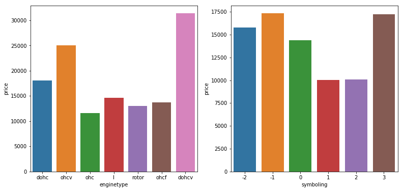

```python
plt.figure(figsize=(20,6))
plt.subplot(1,3,1)
plt1 = sns.barplot(x=data.enginetype,y=data.price,ci=None)

plt.subplot(1,3,2)
plt1 = sns.barplot(x=data.symboling,y=data.price,ci=None)

plt.show()
```

# Visualising numerical data

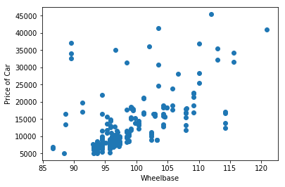

```python
plt.scatter(x = 'wheelbase', y = 'price', data = data)
plt.xlabel('Wheelbase')
plt.ylabel('Price of Car')
plt.show()
```

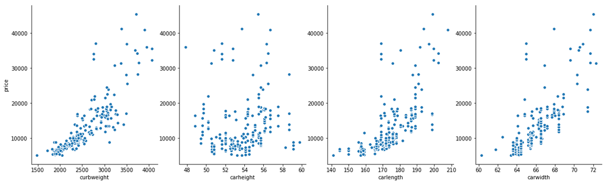

```python
sns.pairplot(data, x_vars=['curbweight','carheight','carlength','carwidth'], y_vars='price',size=5, aspect=0.8, kind='scatter')
```

carheight is not showing correlation

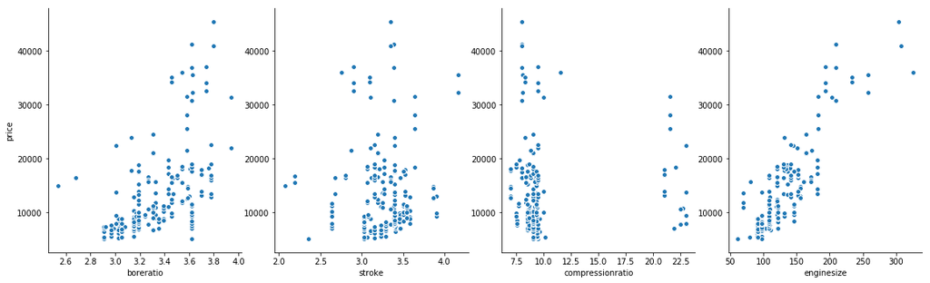

```python
sns.pairplot(data, x_vars=['boreratio','stroke','compressionratio','enginesize'], y_vars='price',size=5, aspect=0.8, kind='scatter')
```

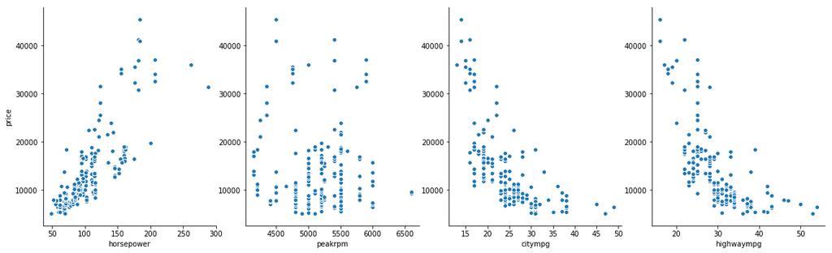

```python
sns.pairplot(data, x_vars=['horsepower','peakrpm','citympg','highwaympg'], y_vars='price',size=5, aspect=0.8, kind='scatter')
```

```python
data['bore_strokeratio']=data['boreratio']/data['stroke']
```

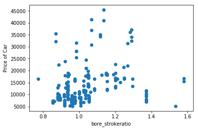

```python
plt.scatter(x = 'bore_strokeratio', y = 'price', data = data)
plt.xlabel('bore_strokeratio')
plt.ylabel('Price of Car')
plt.show()
```

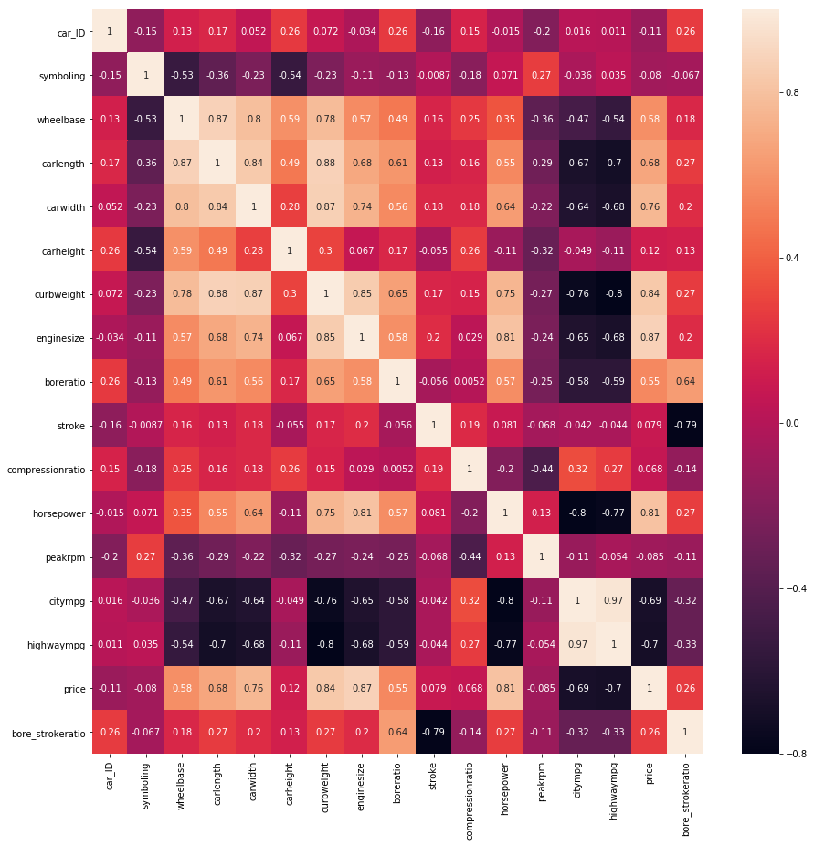

```python
plt.figure(figsize=[15,15])
sns.heatmap(data.corr(),annot=True)
```

Numerical Variables that are less correlated with the price are dropped

# Checking for outliers

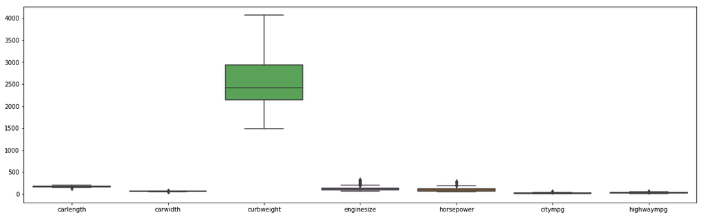

```python
plt.figure(figsize=(20,6))
sns.boxplot(data=data[['carlength','carwidth','curbweight','enginesize','horsepower','citympg','highwaympg']], orient="v",palette="Set1")
```

```python
data.drop(['symboling','wheelbase','carheight','boreratio','stroke', 'compressionratio','peakrpm','doornumber','bore_strokeratio','car_ID'],axis=1,inplace=True)
data.head()
```

|  | CarName | fueltype | aspiration | carbody | drivewheel | enginelocation | carlength | carwidth | curbweight | enginetype | cylindernumber | enginesize | fuelsystem | horsepower | citympg | highwaympg | price |
| --- | --- | --- | --- | --- | --- | --- | --- | --- | --- | --- | --- | --- | --- | --- | --- | --- | --- |
| 0 | alfa-romero | gas | std | convertible | rwd | front | 168.8 | 64.1 | 2548 | dohc | four | 130 | mpfi | 111 | 21 | 27 | 13495.0 |
| 1 | alfa-romero | gas | std | convertible | rwd | front | 168.8 | 64.1 | 2548 | dohc | four | 130 | mpfi | 111 | 21 | 27 | 16500.0 |
| 2 | alfa-romero | gas | std | hatchback | rwd | front | 171.2 | 65.5 | 2823 | ohcv | six | 152 | mpfi | 154 | 19 | 26 | 16500.0 |
| 3 | audi | gas | std | sedan | fwd | front | 176.6 | 66.2 | 2337 | ohc | four | 109 | mpfi | 102 | 24 | 30 | 13950.0 |
| 4 | audi | gas | std | sedan | 4wd | front | 176.6 | 66.4 | 2824 | ohc | five | 136 | mpfi | 115 | 18 | 22 | 17450.0 |

# creating dummy variables

```python
data['fueltype'] = data['fueltype'].map({'gas': 0, 'diesel': 1})
data['aspiration'] = data['aspiration'].map({'std': 0, 'turbo': 1})
data['enginelocation'] = data['enginelocation'].map({'front': 0, 'rear': 1})
```

```python
data.head()
```

|  | CarName | fueltype | aspiration | carbody | drivewheel | enginelocation | carlength | carwidth | curbweight | enginetype | cylindernumber | enginesize | fuelsystem | horsepower | citympg | highwaympg | price |
| --- | --- | --- | --- | --- | --- | --- | --- | --- | --- | --- | --- | --- | --- | --- | --- | --- | --- |
| 0 | alfa-romero | 0 | 0 | convertible | rwd | 0 | 168.8 | 64.1 | 2548 | dohc | four | 130 | mpfi | 111 | 21 | 27 | 13495.0 |
| 1 | alfa-romero | 0 | 0 | convertible | rwd | 0 | 168.8 | 64.1 | 2548 | dohc | four | 130 | mpfi | 111 | 21 | 27 | 16500.0 |
| 2 | alfa-romero | 0 | 0 | hatchback | rwd | 0 | 171.2 | 65.5 | 2823 | ohcv | six | 152 | mpfi | 154 | 19 | 26 | 16500.0 |
| 3 | audi | 0 | 0 | sedan | fwd | 0 | 176.6 | 66.2 | 2337 | ohc | four | 109 | mpfi | 102 | 24 | 30 | 13950.0 |
| 4 | audi | 0 | 0 | sedan | 4wd | 0 | 176.6 | 66.4 | 2824 | ohc | five | 136 | mpfi | 115 | 18 | 22 | 17450.0 |

```python
#dummy var for car name
car = pd.get_dummies(data['CarName'],drop_first=True)
data = pd.concat([data,car],axis=1)
data.drop(['CarName'],axis=1,inplace=True)
```

```python
#dummy var for carbody
body= pd.get_dummies(data['carbody'],drop_first=True)
data = pd.concat([data,body],axis=1)
data.drop(['carbody'],axis=1,inplace=True)
```

```python
#dummy var for drivewheel
d_wheel = pd.get_dummies(data['drivewheel'],drop_first=True)
data = pd.concat([data,d_wheel],axis=1)
data.drop(['drivewheel'],axis=1,inplace=True)
```

```python
#dummy var for enginetype
e_type = pd.get_dummies(data['enginetype'],drop_first=True)
data = pd.concat([data,e_type],axis=1)
data.drop(['enginetype'],axis=1,inplace=True)
```

```python
#dummy var for cylinder number
cylinder= pd.get_dummies(data['cylindernumber'],drop_first=True)
data = pd.concat([data,cylinder],axis=1)
data.drop(['cylindernumber'],axis=1,inplace=True)
```

```python
#dummy var for fuelsystem
fuel_sys= pd.get_dummies(data['fuelsystem'],drop_first=True)
data = pd.concat([data,fuel_sys],axis=1)
data.drop(['fuelsystem'],axis=1,inplace=True)
```

# Rescaling the Features

It is extremely important to rescale the variables so that they have a comparable scale. There are twocoon ways of rescaling

```python
#defining a normalisation function
def normalize (x):
    return ( (x-np.mean(x))/ (max(x) - min(x)))


# applying normalize ( ) to all columns
data = data.apply(normalize)
```

```python
data.columns
```

```
Index(['fueltype', 'aspiration', 'enginelocation', 'carlength', 'carwidth',
       'curbweight', 'enginesize', 'horsepower', 'citympg', 'highwaympg',
       'price', 'audi', 'bmw', 'buick', 'chevrolet', 'dodge', 'honda', 'isuzu',
       'jaguar', 'mazda', 'mercury', 'mitsubishi', 'nissan', 'peugeot',
       'plymouth', 'porsche', 'renault', 'saab', 'subaru', 'toyota',
       'volkswagen', 'volvo', 'hardtop', 'hatchback', 'sedan', 'wagon', 'fwd',
       'rwd', 'dohcv', 'l', 'ohc', 'ohcf', 'ohcv', 'rotor', 'five', 'four',
       'six', 'three', 'twelve', 'two', '2bbl', '4bbl', 'idi', 'mfi', 'mpfi',
       'spdi', 'spfi'],
      dtype='object')
```

```python
# Putting feature variable to X
X = data[['fueltype', 'aspiration', 'enginelocation', 'carlength', 'carwidth',
       'curbweight', 'enginesize', 'horsepower', 'citympg', 'highwaympg',
       'audi', 'bmw', 'buick', 'chevrolet', 'dodge', 'honda', 'isuzu',
       'jaguar', 'mazda', 'mercury', 'mitsubishi', 'nissan', 'peugeot',
       'plymouth', 'porsche', 'renault', 'saab', 'subaru', 'toyota',
       'volkswagen', 'volvo', 'hardtop', 'hatchback', 'sedan', 'wagon', 'fwd',
       'rwd', 'dohcv', 'l', 'ohc', 'ohcf', 'ohcv', 'rotor', 'five', 'four',
       'six', 'three', 'twelve', 'two', '2bbl', '4bbl', 'idi', 'mfi', 'mpfi',
       'spdi', 'spfi']]

# Putting response variable to y
y =data['price']
```

splitting the data (not so necessary in this case study)

```python
#random_state is the seed used by the random number generator, it can be any integer.
from sklearn.cross_validation import train_test_split
X_train, X_test, y_train, y_test = train_test_split(X, y, train_size=0.8 ,test_size = 0.2, random_state=100)
```

# Building model using sklearn

```python
# Importing RFE and LinearRegression
from sklearn.feature_selection import RFE
from sklearn.linear_model import LinearRegression
import statsmodels.api as sm
from statsmodels.stats.outliers_influence import variance_inflation_factor
```

# Model 1

```python
X_train_1 = X_train
#Unlike SKLearn, statsmodels don't automatically fit a constant,
#so you need to use the method sm.add_constant(X) in order to add a constant.
X_train_1 = sm.add_constant(X_train_1)
# create a fitted model in one line
lm_1 = sm.OLS(y_train,X_train_1).fit()

# print the summary
print(lm_1.summary())
```

```
                            OLS Regression Results
==============================================================================
Dep. Variable:                  price   R-squared:                       0.962
Model:                            OLS   Adj. R-squared:                  0.945
Method:                 Least Squares   F-statistic:                     57.06
Date:                Mon, 20 Jul 2020   Prob (F-statistic):           5.15e-61
Time:                        10:08:12   Log-Likelihood:                 307.28
No. Observations:                 164   AIC:                            -512.6
Df Residuals:                     113   BIC:                            -354.5
Df Model:                          50
Covariance Type:            nonrobust
==================================================================================
                     coef    std err          t      P>|t|      [0.025      0.975]
----------------------------------------------------------------------------------
fueltype          -0.0076      0.027     -0.281      0.779      -0.061       0.046
aspiration         0.0158      0.020      0.795      0.428      -0.024       0.055
enginelocation     0.2264      0.053      4.244      0.000       0.121       0.332
carlength         -0.0835      0.086     -0.966      0.336      -0.255       0.088
carwidth           0.2835      0.073      3.905      0.000       0.140       0.427
curbweight         0.2795      0.119      2.354      0.020       0.044       0.515
enginesize         0.0365      0.153      0.238      0.812      -0.267       0.340
horsepower         0.3326      0.137      2.434      0.016       0.062       0.603
citympg            0.0351      0.132      0.266      0.791      -0.227       0.297
highwaympg        -0.0013      0.121     -0.011      0.991      -0.241       0.239
audi              -0.0150      0.053     -0.282      0.778      -0.120       0.090
bmw                0.1693      0.053      3.214      0.002       0.065       0.274
buick              0.0486      0.063      0.768      0.444      -0.077       0.174
chevrolet         -0.0825      0.053     -1.571      0.119      -0.187       0.022
dodge             -0.0880      0.043     -2.061      0.042      -0.173      -0.003
honda             -0.1098      0.063     -1.754      0.082      -0.234       0.014
isuzu             -0.0469      0.048     -0.973      0.332      -0.142       0.049
jaguar             0.1472      0.068      2.150      0.034       0.012       0.283
mazda             -0.0782      0.041     -1.899      0.060      -0.160       0.003
mercury           -0.0925      0.375     -0.247      0.806      -0.836       0.651
mitsubishi        -0.1258      0.044     -2.863      0.005      -0.213      -0.039
nissan            -0.0751      0.039     -1.917      0.058      -0.153       0.003
peugeot           -0.0514      0.044     -1.173      0.243      -0.138       0.035
plymouth          -0.0874      0.044     -1.990      0.049      -0.174      -0.000
porsche            0.0391      0.067      0.583      0.561      -0.094       0.172
renault           -0.1058      0.053     -1.984      0.050      -0.212      -0.000
```

[output cut: 26 more lines]

```
mfi               -0.1056      0.074     -1.425      0.157      -0.252       0.041
mpfi              -0.0493      0.054     -0.918      0.361      -0.156       0.057
spdi              -0.0493      0.058     -0.845      0.400      -0.165       0.066
spfi              -0.0925      0.375     -0.247      0.806      -0.836       0.651
==============================================================================
Omnibus:                       78.129   Durbin-Watson:                   2.202
Prob(Omnibus):                  0.000   Jarque-Bera (JB):              575.280
Skew:                           1.549   Prob(JB):                    1.20e-125
Kurtosis:                      11.636   Cond. No.                     1.54e+16
==============================================================================

Warnings:
[1] Standard Errors assume that the covariance matrix of the errors is correctly specified.
[2] The smallest eigenvalue is 6.54e-31. This might indicate that there are
strong multicollinearity problems or that the design matrix is singular.
```

p value which is greater than 0.05 for the above variables can be eleminated by using RFEmethod. p-value>0.05 is insignificant. RFE=recursive elemination factor,eleminates var with high p value one by one.automatically because of large num of var.

```python
# Running RFE with output number of variable equal to 56
lm = LinearRegression()       #Objecting LinearRegression
rfe = RFE(lm, 40)
rfe = rfe.fit(X_train_1, y_train)
print(rfe.support_)           # Printing boolean results
print(rfe.ranking_)           # printing ranking results
```

```
[False False  True  True  True  True False  True  True False False  True
  True  True  True  True  True  True  True False  True  True  True  True
  True  True False  True  True  True False  True  True  True  True False
 False  True False  True  True  True False  True  True  True False  True
  True False  True False  True  True  True False]
[14 11  1  1  1  1  8  1  1 16  6  1  1  1  1  1  1  1  1 10  1  1  1  1  1
  1  4  1  1  1  7  1  1  1  1 15 13  1  5  1  1  1  3  1  1  1  9  1  1  2
  1 12  1  1  1 17]
```

```python
X_train_1.columns
```

```
Index(['fueltype', 'aspiration', 'enginelocation', 'carlength', 'carwidth',
       'curbweight', 'enginesize', 'horsepower', 'citympg', 'highwaympg',
       'audi', 'bmw', 'buick', 'chevrolet', 'dodge', 'honda', 'isuzu',
       'jaguar', 'mazda', 'mercury', 'mitsubishi', 'nissan', 'peugeot',
       'plymouth', 'porsche', 'renault', 'saab', 'subaru', 'toyota',
       'volkswagen', 'volvo', 'hardtop', 'hatchback', 'sedan', 'wagon', 'fwd',
       'rwd', 'dohcv', 'l', 'ohc', 'ohcf', 'ohcv', 'rotor', 'five', 'four',
       'six', 'three', 'twelve', 'two', '2bbl', '4bbl', 'idi', 'mfi', 'mpfi',
       'spdi', 'spfi'],
      dtype='object')
```

```python
col=X_train_1.columns[rfe.support_]
```

# model 2

```python
# Creating X_test dataframe with RFE selected variables
X_train_2 = X_train[col]
```

```python
# Creating X_test dataframe with RFE selected variables
X_train_2 = X_train[col]
X_train_2 = sm.add_constant(X_train_2)
lm_2 = sm.OLS(y_train,X_train_2).fit()   # Running the linear model

#Let's see the summary of our linear model
print(lm_2.summary())
```

```
                            OLS Regression Results
==============================================================================
Dep. Variable:                  price   R-squared:                       0.961
Model:                            OLS   Adj. R-squared:                  0.949
Method:                 Least Squares   F-statistic:                     78.37
Date:                Mon, 20 Jul 2020   Prob (F-statistic):           1.56e-70
Time:                        10:08:12   Log-Likelihood:                 305.39
No. Observations:                 164   AIC:                            -530.8
Df Residuals:                     124   BIC:                            -406.8
Df Model:                          39
Covariance Type:            nonrobust
==================================================================================
                     coef    std err          t      P>|t|      [0.025      0.975]
----------------------------------------------------------------------------------
const              0.0009      0.003      0.252      0.801      -0.006       0.008
enginelocation     0.2117      0.047      4.521      0.000       0.119       0.304
carlength         -0.0962      0.076     -1.266      0.208      -0.247       0.054
carwidth           0.2769      0.064      4.359      0.000       0.151       0.403
curbweight         0.3338      0.079      4.229      0.000       0.178       0.490
horsepower         0.3772      0.101      3.749      0.000       0.178       0.576
citympg            0.0660      0.053      1.243      0.216      -0.039       0.171
bmw                0.1935      0.031      6.196      0.000       0.132       0.255
buick              0.0845      0.035      2.413      0.017       0.015       0.154
chevrolet         -0.0778      0.036     -2.133      0.035      -0.150      -0.006
dodge             -0.0722      0.024     -2.961      0.004      -0.120      -0.024
honda             -0.0773      0.023     -3.339      0.001      -0.123      -0.031
isuzu             -0.0347      0.032     -1.071      0.286      -0.099       0.029
jaguar             0.1558      0.043      3.664      0.000       0.072       0.240
mazda             -0.0626      0.021     -2.931      0.004      -0.105      -0.020
mitsubishi        -0.1150      0.025     -4.632      0.000      -0.164      -0.066
nissan            -0.0627      0.021     -2.985      0.003      -0.104      -0.021
peugeot           -0.0629      0.037     -1.704      0.091      -0.136       0.010
plymouth          -0.0745      0.027     -2.772      0.006      -0.128      -0.021
porsche            0.0597      0.050      1.199      0.233      -0.039       0.158
renault           -0.0846      0.035     -2.436      0.016      -0.153      -0.016
subaru            -0.1342      0.032     -4.186      0.000      -0.198      -0.071
toyota            -0.0696      0.018     -3.961      0.000      -0.104      -0.035
volkswagen        -0.0568      0.019     -3.027      0.003      -0.094      -0.020
hardtop           -0.0830      0.034     -2.413      0.017      -0.151      -0.015
hatchback         -0.0783      0.028     -2.791      0.006      -0.134      -0.023
```

[output cut: 11 more lines]

```
4bbl              -0.0490      0.052     -0.941      0.348      -0.152       0.054
mfi               -0.0771      0.050     -1.528      0.129      -0.177       0.023
mpfi              -0.0291      0.015     -1.890      0.061      -0.060       0.001
spdi              -0.0155      0.026     -0.598      0.551      -0.067       0.036
==============================================================================
Omnibus:                       72.077   Durbin-Watson:                   2.188
Prob(Omnibus):                  0.000   Jarque-Bera (JB):              472.193
Skew:                           1.440   Prob(JB):                    2.91e-103
Kurtosis:                      10.798   Cond. No.                     1.00e+16
==============================================================================

Warnings:
[1] Standard Errors assume that the covariance matrix of the errors is correctly specified.
[2] The smallest eigenvalue is 1.64e-30. This might indicate that there are
strong multicollinearity problems or that the design matrix is singular.
```

```python
lm = LinearRegression()       #Objecting LinearRegression
rfe = RFE(lm, 30)
rfe = rfe.fit(X_train_2, y_train)
print(rfe.support_)           # Printing boolean results
print(rfe.ranking_)           # printing ranking results
```

```
[False  True  True  True  True  True  True  True  True False  True False
 False  True False  True  True  True  True  True  True  True  True  True
  True  True  True  True  True False  True False  True  True  True  True
 False False  True False False]
[12  1  1  1  1  1  1  1  1  3  1  2  7  1  4  1  1  1  1  1  1  1  1  1  1
  1  1  1  1  5  1  9  1  1  1  1 10  6  1  8 11]
```

```python
X_train_2.columns
```

```
Index(['const', 'enginelocation', 'carlength', 'carwidth', 'curbweight',
       'horsepower', 'citympg', 'bmw', 'buick', 'chevrolet', 'dodge', 'honda',
       'isuzu', 'jaguar', 'mazda', 'mitsubishi', 'nissan', 'peugeot',
       'plymouth', 'porsche', 'renault', 'subaru', 'toyota', 'volkswagen',
       'hardtop', 'hatchback', 'sedan', 'wagon', 'dohcv', 'ohc', 'ohcf',
       'ohcv', 'five', 'four', 'six', 'twelve', 'two', '4bbl', 'mfi', 'mpfi',
       'spdi'],
      dtype='object')
```

# Model 3

```python
col=X_train_2.columns[rfe.support_]
```

```python
X_train_3 = X_train[col]
X_train_3 = sm.add_constant(X_train_3)
lm_3 = sm.OLS(y_train,X_train_3).fit()   # Running the linear model

#Let's see the summary of our linear model
print(lm_3.summary())
```

```
                            OLS Regression Results
==============================================================================
Dep. Variable:                  price   R-squared:                       0.955
Model:                            OLS   Adj. R-squared:                  0.945
Method:                 Least Squares   F-statistic:                     98.24
Date:                Mon, 20 Jul 2020   Prob (F-statistic):           2.14e-76
Time:                        10:08:13   Log-Likelihood:                 293.78
No. Observations:                 164   AIC:                            -527.6
Df Residuals:                     134   BIC:                            -434.6
Df Model:                          29
Covariance Type:            nonrobust
==================================================================================
                     coef    std err          t      P>|t|      [0.025      0.975]
----------------------------------------------------------------------------------
const              0.0005      0.004      0.137      0.891      -0.007       0.008
enginelocation     0.2176      0.045      4.867      0.000       0.129       0.306
carlength         -0.0411      0.069     -0.597      0.551      -0.177       0.095
carwidth           0.2637      0.058      4.583      0.000       0.150       0.377
curbweight         0.3923      0.076      5.180      0.000       0.242       0.542
horsepower         0.2838      0.074      3.809      0.000       0.136       0.431
citympg            0.1054      0.044      2.371      0.019       0.017       0.193
bmw                0.2502      0.023     10.744      0.000       0.204       0.296
buick              0.1022      0.032      3.164      0.002       0.038       0.166
dodge             -0.0144      0.018     -0.786      0.434      -0.051       0.022
jaguar             0.1721      0.039      4.395      0.000       0.095       0.250
mitsubishi        -0.0579      0.016     -3.606      0.000      -0.090      -0.026
nissan            -0.0182      0.015     -1.248      0.214      -0.047       0.011
peugeot           -0.0751      0.023     -3.204      0.002      -0.121      -0.029
plymouth          -0.0177      0.022     -0.814      0.417      -0.061       0.025
porsche            0.1123      0.049      2.297      0.023       0.016       0.209
renault           -0.0584      0.034     -1.743      0.084      -0.125       0.008
subaru            -0.1285      0.025     -5.153      0.000      -0.178      -0.079
toyota            -0.0292      0.013     -2.307      0.023      -0.054      -0.004
volkswagen        -0.0284      0.015     -1.845      0.067      -0.059       0.002
hardtop           -0.0949      0.032     -2.960      0.004      -0.158      -0.031
hatchback         -0.0909      0.025     -3.668      0.000      -0.140      -0.042
sedan             -0.0767      0.026     -3.000      0.003      -0.127      -0.026
wagon             -0.0962      0.027     -3.563      0.001      -0.150      -0.043
dohcv             -0.1661      0.077     -2.148      0.033      -0.319      -0.013
ohcf               0.0891      0.022      3.968      0.000       0.045       0.134
five              -0.0482      0.024     -1.988      0.049      -0.096      -0.000
four              -0.0602      0.021     -2.818      0.006      -0.103      -0.018
six               -0.0723      0.028     -2.568      0.011      -0.128      -0.017
twelve            -0.1251      0.069     -1.807      0.073      -0.262       0.012
mfi               -0.0588      0.049     -1.194      0.235      -0.156       0.039
==============================================================================
Omnibus:                       57.832   Durbin-Watson:                   1.970
Prob(Omnibus):                  0.000   Jarque-Bera (JB):              306.264
Skew:                           1.164   Prob(JB):                     3.13e-67
Kurtosis:                       9.277   Cond. No.                     2.25e+15
==============================================================================

Warnings:
[1] Standard Errors assume that the covariance matrix of the errors is correctly specified.
[2] The smallest eigenvalue is 3.24e-29. This might indicate that there are
strong multicollinearity problems or that the design matrix is singular.
```

```python
lm = LinearRegression()       #Objecting LinearRegression
rfe = RFE(lm, 10)
rfe = rfe.fit(X_train_3, y_train)
print(rfe.support_)           # Printing boolean results
print(rfe.ranking_)           # printing ranking results
```

```
[False  True False  True  True  True False  True  True False  True False
 False False False  True False  True False False False False False False
 False  True False False False False False]
[22  1 14  1  1  1  8  1  1 21  1 15 20 12 19  1 16  1 18 17  2  4  5  3  6
  1 11  9 10  7 13]
```

```python
X_train_3.columns
```

```
Index(['const', 'enginelocation', 'carlength', 'carwidth', 'curbweight',
       'horsepower', 'citympg', 'bmw', 'buick', 'dodge', 'jaguar',
       'mitsubishi', 'nissan', 'peugeot', 'plymouth', 'porsche', 'renault',
       'subaru', 'toyota', 'volkswagen', 'hardtop', 'hatchback', 'sedan',
       'wagon', 'dohcv', 'ohcf', 'five', 'four', 'six', 'twelve', 'mfi'],
      dtype='object')
```

```python
X_train_3.columns[rfe.support_]
```

```
Index(['enginelocation', 'carwidth', 'curbweight', 'horsepower', 'bmw',
       'buick', 'jaguar', 'porsche', 'subaru', 'ohcf'],
      dtype='object')
```

```python
col=X_train_3.columns[rfe.support_]
```

# Model 4

```python
X_train_4 = X_train[col]
X_train_4 = sm.add_constant(X_train_4)
lm_4 = sm.OLS(y_train,X_train_4).fit()   # Running the linear model

#Let's see the summary of our linear model
print(lm_4.summary())
```

```
                            OLS Regression Results
==============================================================================
Dep. Variable:                  price   R-squared:                       0.929
Model:                            OLS   Adj. R-squared:                  0.925
Method:                 Least Squares   F-statistic:                     225.2
Date:                Mon, 20 Jul 2020   Prob (F-statistic):           6.89e-84
Time:                        10:08:13   Log-Likelihood:                 256.68
No. Observations:                 164   AIC:                            -493.4
Df Residuals:                     154   BIC:                            -462.4
Df Model:                           9
Covariance Type:            nonrobust
==================================================================================
                     coef    std err          t      P>|t|      [0.025      0.975]
----------------------------------------------------------------------------------
const              0.0003      0.004      0.082      0.935      -0.008       0.008
enginelocation     0.2565      0.037      6.916      0.000       0.183       0.330
carwidth           0.2595      0.048      5.369      0.000       0.164       0.355
curbweight         0.2426      0.051      4.727      0.000       0.141       0.344
horsepower         0.2539      0.047      5.401      0.000       0.161       0.347
bmw                0.2745      0.023     12.014      0.000       0.229       0.320
buick              0.2181      0.028      7.858      0.000       0.163       0.273
jaguar             0.2258      0.035      6.412      0.000       0.156       0.295
porsche            0.1004      0.042      2.365      0.019       0.017       0.184
subaru            -0.1428      0.021     -6.699      0.000      -0.185      -0.101
ohcf               0.1137      0.019      5.927      0.000       0.076       0.152
==============================================================================
Omnibus:                       46.749   Durbin-Watson:                   1.894
Prob(Omnibus):                  0.000   Jarque-Bera (JB):              125.083
Skew:                           1.159   Prob(JB):                     6.89e-28
Kurtosis:                       6.596   Cond. No.                     1.82e+16
==============================================================================

Warnings:
[1] Standard Errors assume that the covariance matrix of the errors is correctly specified.
[2] The smallest eigenvalue is 4.93e-31. This might indicate that there are
strong multicollinearity problems or that the design matrix is singular.
```

# using RFE we eliminated some features then retaining 10 features furthur insignificant and multicollinaear features are eliminated manually

if p>0.05 and VIF>2 are eliminated manually.one by one

# VIF and eliminate the variables manually

```python
X_train_4.shape
```

```
(164, 11)
```

```python
def checkVIF(X):
    vif = pd.DataFrame()
    vif['Features'] = X.columns
    vif['VIF'] = [variance_inflation_factor(X.values, i) for i in range(X.shape[1])]
    vif['VIF'] = round(vif['VIF'], 2)
    vif = vif.sort_values(by = "VIF", ascending = False)
    return(vif)
```

```python
checkVIF(X_train_4)
```

|  | Features | VIF |
| --- | --- | --- |
| 1 | enginelocation | inf |
| 9 | subaru | inf |
| 10 | ohcf | inf |
| 3 | curbweight | 6.450000 |
| 2 | carwidth | 4.530000 |
| 4 | horsepower | 3.560000 |
| 8 | porsche | 2.580000 |
| 6 | buick | 1.370000 |
| 7 | jaguar | 1.340000 |
| 5 | bmw | 1.110000 |
| 0 | const | 1.020000 |

```python
X_train_new = X_train_4.drop(["enginelocation"], axis = 1)
```

# Model 5

```python
X_train_5 = X_train_new
X_train_5 = sm.add_constant(X_train_5)
lm_5 = sm.OLS(y_train,X_train_5).fit()   # Running the linear model

#Let's see the summary of our linear model
print(lm_5.summary())
```

```
                            OLS Regression Results
==============================================================================
Dep. Variable:                  price   R-squared:                       0.929
Model:                            OLS   Adj. R-squared:                  0.925
Method:                 Least Squares   F-statistic:                     225.2
Date:                Mon, 20 Jul 2020   Prob (F-statistic):           6.89e-84
Time:                        10:39:40   Log-Likelihood:                 256.68
No. Observations:                 164   AIC:                            -493.4
Df Residuals:                     154   BIC:                            -462.4
Df Model:                           9
Covariance Type:            nonrobust
==============================================================================
                 coef    std err          t      P>|t|      [0.025      0.975]
------------------------------------------------------------------------------
const          0.0003      0.004      0.082      0.935      -0.008       0.008
carwidth       0.2595      0.048      5.369      0.000       0.164       0.355
curbweight     0.2426      0.051      4.727      0.000       0.141       0.344
horsepower     0.2539      0.047      5.401      0.000       0.161       0.347
bmw            0.2745      0.023     12.014      0.000       0.229       0.320
buick          0.2181      0.028      7.858      0.000       0.163       0.273
jaguar         0.2258      0.035      6.412      0.000       0.156       0.295
porsche        0.1004      0.042      2.365      0.019       0.017       0.184
subaru        -0.3993      0.057     -6.959      0.000      -0.513      -0.286
ohcf           0.3702      0.055      6.722      0.000       0.261       0.479
==============================================================================
Omnibus:                       46.749   Durbin-Watson:                   1.894
Prob(Omnibus):                  0.000   Jarque-Bera (JB):              125.083
Skew:                           1.159   Prob(JB):                     6.89e-28
Kurtosis:                       6.596   Cond. No.                         21.6
==============================================================================

Warnings:
[1] Standard Errors assume that the covariance matrix of the errors is correctly specified.
```

```python
checkVIF(X_train_5)
```

|  | Features | VIF |
| --- | --- | --- |
| 9 | ohcf | 13.32 |
| 8 | subaru | 12.40 |
| 2 | curbweight | 6.45 |
| 1 | carwidth | 4.53 |
| 3 | horsepower | 3.56 |
| 7 | porsche | 2.58 |
| 5 | buick | 1.37 |
| 6 | jaguar | 1.34 |
| 4 | bmw | 1.11 |
| 0 | const | 1.02 |

```python
X_train_new = X_train_5.drop(["ohcf","subaru"], axis = 1)
```

# Model 6

```python
X_train_6 = X_train_new
X_train_6 = sm.add_constant(X_train_6)
lm_6 = sm.OLS(y_train,X_train_6).fit()   # Running the linear model

#Let's see the summary of our linear model
print(lm_6.summary())
```

```
                            OLS Regression Results
==============================================================================
Dep. Variable:                  price   R-squared:                       0.907
Model:                            OLS   Adj. R-squared:                  0.903
Method:                 Least Squares   F-statistic:                     217.7
Date:                Mon, 20 Jul 2020   Prob (F-statistic):           4.11e-77
Time:                        10:39:41   Log-Likelihood:                 234.24
No. Observations:                 164   AIC:                            -452.5
Df Residuals:                     156   BIC:                            -427.7
Df Model:                           7
Covariance Type:            nonrobust
==============================================================================
                 coef    std err          t      P>|t|      [0.025      0.975]
------------------------------------------------------------------------------
const         -0.0008      0.005     -0.169      0.866      -0.010       0.008
carwidth       0.1583      0.052      3.027      0.003       0.055       0.262
curbweight     0.3046      0.058      5.293      0.000       0.191       0.418
horsepower     0.2690      0.054      5.027      0.000       0.163       0.375
bmw            0.2714      0.026     10.437      0.000       0.220       0.323
buick          0.2333      0.032      7.399      0.000       0.171       0.296
jaguar         0.2204      0.040      5.495      0.000       0.141       0.300
porsche        0.2869      0.037      7.803      0.000       0.214       0.360
==============================================================================
Omnibus:                       32.815   Durbin-Watson:                   1.907
Prob(Omnibus):                  0.000   Jarque-Bera (JB):               78.368
Skew:                           0.839   Prob(JB):                     9.61e-18
Kurtosis:                       5.941   Cond. No.                         16.4
==============================================================================

Warnings:
[1] Standard Errors assume that the covariance matrix of the errors is correctly specified.
```

```python
checkVIF(X_train_6)
```

|  | Features | VIF |
| --- | --- | --- |
| 2 | curbweight | 6.25 |
| 1 | carwidth | 4.08 |
| 3 | horsepower | 3.55 |
| 7 | porsche | 1.49 |
| 5 | buick | 1.36 |
| 6 | jaguar | 1.34 |
| 4 | bmw | 1.10 |
| 0 | const | 1.01 |

```python
X_train_new = X_train_6.drop(["curbweight"], axis = 1)
```

# Model 7

```python
X_train_7 = X_train_new
X_train_7 = sm.add_constant(X_train_7)
lm_7 = sm.OLS(y_train,X_train_7).fit()   # Running the linear model

#Let's see the summary of our linear model
print(lm_7.summary())
```

```
                            OLS Regression Results
==============================================================================
Dep. Variable:                  price   R-squared:                       0.890
Model:                            OLS   Adj. R-squared:                  0.886
Method:                 Least Squares   F-statistic:                     212.8
Date:                Mon, 20 Jul 2020   Prob (F-statistic):           1.01e-72
Time:                        10:39:48   Log-Likelihood:                 220.70
No. Observations:                 164   AIC:                            -427.4
Df Residuals:                     157   BIC:                            -405.7
Df Model:                           6
Covariance Type:            nonrobust
==============================================================================
                 coef    std err          t      P>|t|      [0.025      0.975]
------------------------------------------------------------------------------
const         -0.0012      0.005     -0.232      0.817      -0.011       0.009
carwidth       0.3452      0.042      8.269      0.000       0.263       0.428
horsepower     0.4098      0.050      8.154      0.000       0.311       0.509
bmw            0.2906      0.028     10.427      0.000       0.236       0.346
buick          0.2736      0.033      8.262      0.000       0.208       0.339
jaguar         0.2750      0.042      6.555      0.000       0.192       0.358
porsche        0.2430      0.039      6.266      0.000       0.166       0.320
==============================================================================
Omnibus:                       36.164   Durbin-Watson:                   1.985
Prob(Omnibus):                  0.000   Jarque-Bera (JB):              117.419
Skew:                           0.807   Prob(JB):                     3.18e-26
Kurtosis:                       6.818   Cond. No.                         12.8
==============================================================================

Warnings:
[1] Standard Errors assume that the covariance matrix of the errors is correctly specified.
```

```python
checkVIF(X_train_7)
```

|  | Features | VIF |
| --- | --- | --- |
| 2 | horsepower | 2.67 |
| 1 | carwidth | 2.22 |
| 6 | porsche | 1.42 |
| 4 | buick | 1.28 |
| 5 | jaguar | 1.25 |
| 3 | bmw | 1.08 |
| 0 | const | 1.01 |

# After dropping some variables we endup with features above which have no multicolliniarity and also significant

# Inference:the company should focus more on the variables like horsepower,carwidth and car comapnies like porsche,buick,bmw,jaguar

# Making Predictions

```python
X_train_7=X_train_7.drop(['const'],1)
```

```python
X_train_7.columns
```

```
Index(['carwidth', 'horsepower', 'bmw', 'buick', 'jaguar', 'porsche'], dtype='object')
```

```python
X_test.columns
```

```
Index(['fueltype', 'aspiration', 'enginelocation', 'carlength', 'carwidth',
       'curbweight', 'enginesize', 'horsepower', 'citympg', 'highwaympg',
       'audi', 'bmw', 'buick', 'chevrolet', 'dodge', 'honda', 'isuzu',
       'jaguar', 'mazda', 'mercury', 'mitsubishi', 'nissan', 'peugeot',
       'plymouth', 'porsche', 'renault', 'saab', 'subaru', 'toyota',
       'volkswagen', 'volvo', 'hardtop', 'hatchback', 'sedan', 'wagon', 'fwd',
       'rwd', 'dohcv', 'l', 'ohc', 'ohcf', 'ohcv', 'rotor', 'five', 'four',
       'six', 'three', 'twelve', 'two', '2bbl', '4bbl', 'idi', 'mfi', 'mpfi',
       'spdi', 'spfi'],
      dtype='object')
```

```python
X_test_new=X_test.drop(['fueltype', 'aspiration', 'enginelocation', 'carlength',
       'curbweight', 'enginesize', 'citympg', 'highwaympg',
       'audi', 'chevrolet', 'dodge', 'honda', 'isuzu',
       'mazda', 'mercury', 'mitsubishi', 'nissan', 'peugeot',
       'plymouth','renault', 'saab', 'subaru', 'toyota',
       'volkswagen', 'volvo', 'hardtop', 'hatchback', 'sedan', 'wagon', 'fwd',
       'rwd', 'dohcv', 'l', 'ohc', 'ohcf', 'ohcv', 'rotor', 'five', 'four',
       'six', 'three', 'twelve', 'two', '2bbl', '4bbl', 'idi', 'mfi', 'mpfi',
       'spdi', 'spfi'],axis=1)
```

```python
# Making predictions using the model
lm.fit(X_train_7,y_train)
y_pred = lm.predict(X_test_new)
from sklearn.metrics import mean_squared_error, r2_score
mse = mean_squared_error(y_test, y_pred)
r_squared = r2_score(y_test, y_pred)
print('Mean_Squared_Error :' ,mse)
print('r_square_value :',r_squared)
```

```
Mean_Squared_Error : 0.00494430431493
r_square_value : 0.895859934167
```

```python
y_pred.shape
```

```
(41,)
```

# the r-square value of training is "0.886" and of testing is "0.895". our model can explain 90% variance

# Lets evaluate the model performance

```
Text(0,0.5,'car price')
```

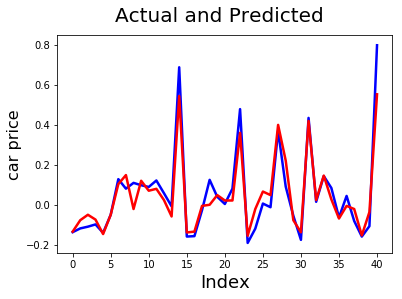

```python
# Actual and Predicted
import matplotlib.pyplot as plt
c = [i for i in range(0,41,1)] # generating index
fig = plt.figure()
plt.plot(c,y_test, color="blue", linewidth=2.5, linestyle="-") #Plotting Actual
plt.plot(c,y_pred, color="red",  linewidth=2.5, linestyle="-") #Plotting predicted
fig.suptitle('Actual and Predicted', fontsize=20)              # Plot heading
plt.xlabel('Index', fontsize=18)                               # X-label
plt.ylabel('car price', fontsize=16)
```

```
Text(0,0.5,'ytest-ypred')
```

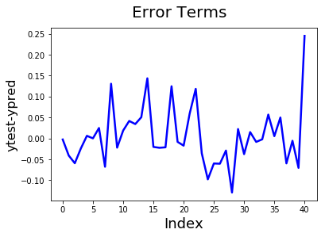

```python
# Error terms
c = [i for i in range(0,41,1)]
fig = plt.figure()
plt.plot(c,y_test-y_pred, color="blue", linewidth=2.5, linestyle="-")
fig.suptitle('Error Terms', fontsize=20)              # Plot heading
plt.xlabel('Index', fontsize=18)                      # X-label
plt.ylabel('ytest-ypred', fontsize=16)
```

Error term shows constant variance throughout the data

```
Text(0,0.5,'y_pred')
```

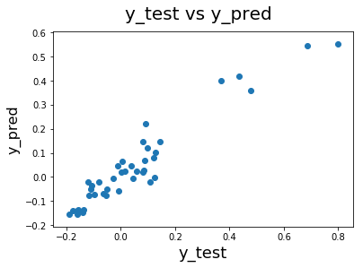

```python
# Plotting y_test and y_pred to understand the spread.
fig = plt.figure()
plt.scatter(y_test,y_pred)
fig.suptitle('y_test vs y_pred', fontsize=20)              # Plot heading
plt.xlabel('y_test', fontsize=18)                          # X-label
plt.ylabel('y_pred', fontsize=16)                          # Y-label
```

Linearity observed for y_test y_pred

```
Text(0,0.5,'Index')
```

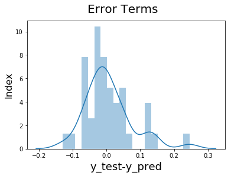

```python
# Plotting the error terms to understand the distribution.
fig = plt.figure()
sns.distplot((y_test-y_pred),bins=20)
fig.suptitle('Error Terms', fontsize=20)                  # Plot heading
plt.xlabel('y_test-y_pred', fontsize=18)                  # X-label
plt.ylabel('Index', fontsize=16)                          # Y-label
```

Error is distributed normally

# Data set is small, so just trying the entire dataset to fit the model without training and testing samples , using the already selected imp features

```python
data.columns
```

```
Index(['fueltype', 'aspiration', 'enginelocation', 'carlength', 'carwidth',
       'curbweight', 'enginesize', 'horsepower', 'citympg', 'highwaympg',
       'price', 'audi', 'bmw', 'buick', 'chevrolet', 'dodge', 'honda', 'isuzu',
       'jaguar', 'mazda', 'mercury', 'mitsubishi', 'nissan', 'peugeot',
       'plymouth', 'porsche', 'renault', 'saab', 'subaru', 'toyota',
       'volkswagen', 'volvo', 'hardtop', 'hatchback', 'sedan', 'wagon', 'fwd',
       'rwd', 'dohcv', 'l', 'ohc', 'ohcf', 'ohcv', 'rotor', 'five', 'four',
       'six', 'three', 'twelve', 'two', '2bbl', '4bbl', 'idi', 'mfi', 'mpfi',
       'spdi', 'spfi'],
      dtype='object')
```

```python
Full_data_x=data.drop(['fueltype', 'aspiration', 'enginelocation', 'carlength',
       'curbweight', 'enginesize', 'citympg', 'highwaympg',
       'audi',  'chevrolet', 'dodge', 'honda', 'isuzu',
       'mazda', 'mercury', 'mitsubishi', 'nissan', 'peugeot',
       'plymouth', 'renault', 'saab', 'subaru', 'toyota',
       'volkswagen', 'volvo', 'hardtop', 'hatchback', 'sedan', 'wagon', 'fwd',
       'rwd', 'dohcv', 'l', 'ohc', 'ohcf', 'ohcv', 'rotor', 'five', 'four',
       'six', 'three', 'twelve', 'two', '2bbl', '4bbl', 'idi', 'mfi', 'mpfi',
       'spdi', 'spfi','price'],axis=1)
```

```python
Full_data_x.columns
```

```
Index(['carwidth', 'horsepower', 'bmw', 'buick', 'jaguar', 'porsche'], dtype='object')
```

```python
Full_data_y=data['price']
```

```python
Full_data_x = sm.add_constant(Full_data_x)
lm_fulldata = sm.OLS(Full_data_y,Full_data_x).fit()
print(lm_fulldata.summary())
```

```
                            OLS Regression Results
==============================================================================
Dep. Variable:                  price   R-squared:                       0.896
Model:                            OLS   Adj. R-squared:                  0.893
Method:                 Least Squares   F-statistic:                     285.7
Date:                Mon, 20 Jul 2020   Prob (F-statistic):           1.29e-94
Time:                        10:33:36   Log-Likelihood:                 273.71
No. Observations:                 205   AIC:                            -533.4
Df Residuals:                     198   BIC:                            -510.2
Df Model:                           6
Covariance Type:            nonrobust
==============================================================================
                 coef    std err          t      P>|t|      [0.025      0.975]
------------------------------------------------------------------------------
const       3.296e-17      0.005   7.28e-15      1.000      -0.009       0.009
carwidth       0.3428      0.038      8.913      0.000       0.267       0.419
horsepower     0.4351      0.044      9.877      0.000       0.348       0.522
bmw            0.2726      0.024     11.224      0.000       0.225       0.321
buick          0.3151      0.027     11.527      0.000       0.261       0.369
jaguar         0.2651      0.041      6.474      0.000       0.184       0.346
porsche        0.2557      0.035      7.380      0.000       0.187       0.324
==============================================================================
Omnibus:                       34.590   Durbin-Watson:                   1.355
Prob(Omnibus):                  0.000   Jarque-Bera (JB):              127.484
Skew:                           0.587   Prob(JB):                     2.08e-28
Kurtosis:                       6.680   Cond. No.                         12.7
==============================================================================

Warnings:
[1] Standard Errors assume that the covariance matrix of the errors is correctly specified.
```

```python
checkVIF(Full_data_x)
```

|  | Features | VIF |
| --- | --- | --- |
| 2 | horsepower | 2.56 |
| 1 | carwidth | 2.30 |
| 6 | porsche | 1.40 |
| 4 | buick | 1.37 |
| 5 | jaguar | 1.18 |
| 3 | bmw | 1.08 |
| 0 | const | 1.00 |

# No Multicollinearity and high r-quare value of .896 and adjusted r-square of 0.893